# 計量経済学応用

授業を受ける準備

矢内 勇生

2021-04-03（改訂：2022-04-05, 2023-09-30, 2026-02-05, 2026-02-16, 2026-09-29）

## R と RStudio

### Rのバージョンについて

この授業が始まる2026年10月2日時点では、R 4.6.1 （2026年6月24日公開）が最新バージョンである。 しかし、多くの受講生のパソコンにインストールされているのは、今年度開始時点で最新版だった R 4.5.3 だと思われるので、この授業では R 4.5.3 を利用する。最新版でも大きな問題はない。自分のパソコンに R 4.5.3 をインストールしたい場合は、以下のリンク先で手に入れることができる。

- macOS (Apple silicon) 用 R-4.5.3-arm64.pkg：https://ftp.yz.yamagata-u.ac.jp/pub/cran/bin/macosx/big-sur-arm64/base/
- Windows 用 R-4.5.3-win.exe：https://cran.r-project.org/bin/windows/base/old/4.5.3/
- Linux用（ソースコード）R-4.5.3.tar.gz：https://cran.r-project.org/src/base/R-4/

### RStudio のバージョンについて

古いバージョンのRStudio を使っているなら最新版に更新したほうがよい。自分が使っているバージョンは、RStudio メニューの “About RStudio” で確認することができる。この資料を作成している時点での最新版は、2026.09.0+174 である。最新版にするためには、[RStudio Desktop](https://posit.co/download/rstudio-desktop/) をインストールし直せばよい。

## プロジェクトの作成

新しい授業なので、RStudio で新しいプロジェクトを作っておこう。 名前の付け方はルール通りならなんでもかまわない。たとえば、 `metrics_applied` などにしておけばよいだろう。 プロジェクトができたら、データ保存用の `data` ディレクトリと、図を保存するための `figs` ディレクトリを以下のコードで作る。

```r
dir.create("data")
dir.create("figs")
```

## 必要なパッケージのインストール

次回以降、さまざまなRパッケージを利用する。 各回で必要なパッケージはそれぞれの実習資料の冒頭に記すが、全体を通じて利用するパッケージをここで紹介する。必要に応じてインストールすること。

まず、全体を通じて **tidyverse** を利用する。統計学2と計量経済学でも利用したので説明不要だ思うが、 tidyverseは**ggplot2**、**dplyr**、**tibble**、**readr** などの便利なパッケージをまとめたパッケージ群である。 tidyverseを使うと、データの整形・変形を簡単に行えるようになり、コードの可読性を高めることができるというメリットがある。データの可視化には、tidyverse の一部である ggplot2 を使う。 このパッケージをインストール済みでない場合は、

```r
install.packages("tidyverse")
```

でインストールする。

次に、パッケージの読み込みとインストールに利用する **pacman**と**pak** をインストールする。

```r
install.packages(c("pacman", "pak"))
```

これまでの授業では、 `install.packages()` でパッケージをインストールし、インストール済みのパッケージを `library()` で読み込むという、Rパッケージの標準的な使い方をしてきた。しかし、この方法を使う場合、 `library()` で読み込むパッケージをあらかじめインストールしておかなければならない。Rで分析をする際には多数のパッケージを利用するので、インストール済みかどうか全部覚えておくのは難しい。この問題は、 `pacman::p_load()` を使うことで（多くの場合）解決する。 `pacman::p_load()` というのは、**pacman**パッケージに含まれる `p_load()` 関数という意味である。このように、 `パッケージ名::関数名()` という書き方があったことを思い出してほしい。この表記を利用すると、異なるパッケージに含まれる同じ名前の関数を区別して使うことができる。

`p_load()`の利点は2つある。第1に、インストール済みでないパッケージを指定すると、それをインスト－ルしてから読み込んでくれる。ただし、これが使えるのはCRANに登録されているパッケージだけである。CRANに登録されていないパッケージのインストール法は後ほど説明する。第2に、複数パッケージの読み込みが一度に簡単にできる。

pacmanを使って、既にインストール済みの tidyverse と、まだインストールしていないかもしれない**patchwork**、**estimatr**、**remotes** の計4つのパッケージを同時に読み込んでみよう。

```r
pacman::p_load(tidyverse,
               patchwork,
               estimatr,
               remotes)
```

これで4つのパッケージが使えるようになっているはずだ。tibble とggplot2 (どちらもtidyverseに含まれる)、patchwork が使えることを確認するために、以下のコードを実行してみよう。

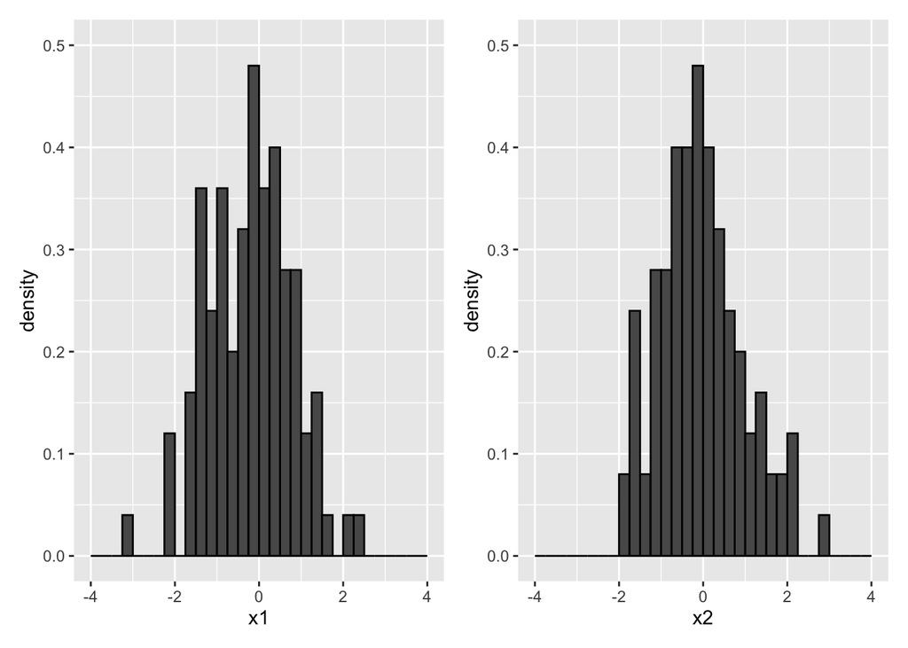

```r
set.seed(2021-03-21)
myd <- tibble(x1 = rnorm(100),
              x2 = rnorm(100))
p1 <- ggplot(myd, aes(x = x1,
                      y = after_stat(density))) +
  geom_histogram(binwidth = 0.25,
                 boundary = 0,
                 color = "black") +
  xlim(-4, 4) +
  ylim( 0, 0.5)
p2 <- ggplot(myd, aes(x = x2,
                      y = after_stat(density))) +
  geom_histogram(binwidth = 0.25,
                 boundary = 0,
                 color = "black") +
  xlim(-4, 4) +
  ylim( 0, 0.5)
plot(p1 + p2)
```

このコードでは、tibbleで作ったデータフレーム (tibble) を使って gglot2で図を作り、作った2つの図を patchwork で並べて表示している。

pacman を使わずに複数のパッケージを一度にインストールし、それらを読み込むためには、次のようなコードを書く必要がある。

```r
install.packages(c("patchwork", "estimatr", "remotes"))
sapply(c("tidyverse", "patchwork", "estimatr", "remotes"),
       require, character.only = TRUE)
```

一見してわかるとおり、pacman を使ったほうが楽である。

ただし、[CRAN](https://cloud.r-project.org/) に登録されていないパッケージは手動でインストールする必要がある。GitHub にアップロードされているパッケージは、`pakdevtools::install_github()`、`remotes::install_github()`、あるいは`pak::pak()` でインストールする。例として、宋財泫 (SONG Jaehyun) 氏がGitHub で公開している [**BalanceR** パッケージ](https://github.com/JaehyunSong/BalanceR) をインストールしてみよう。

```r
pak::pak("JaehyunSong/BalanceR")
```

インストールさえ済めば、`pacman::p_load()` で読み込みができる。

```r
pacman::p_load(BalanceR)
```

これで BalanceR パッケージが使える。

このように、GitHub からパッケージをインストールする際には、パッケージ名だけでなく、そのパッケージを公開しているGitHubのアカウント名（この例では JaehyunSong）を併せて指定する必要がある。

最後に、ggplot2 の図で日本語を正しく表示するための下準備をしておこう。 使用するOSにかかわらず以下のコードブロックを`pacman::p_load(tidyverse)` の後に実行すれば日本語が正しく表示される（はず）。もちろん、以下のうち自分のOSに関係がある部分だけを実行してもよい。Linux の場合は IPAexGothic フォントをあらかじめインストールしておく必要がある（他のフォントを使ってもよい）。

```r
if (.Platform$OS.type == "windows") { # Windows
  my_font <- "Yu Gothic"
} else if (capabilities("aqua")) { # macOS
  my_font <- "HiraginoSans-W3"
} else { # Unix/Linux
  my_font <- "IPAexGothic"
}
## ggplot2 用の設定
theme_set(theme_gray(base_size = 9,
                     base_family = my_font))
```

試しに、日本語を含む図を表示する。

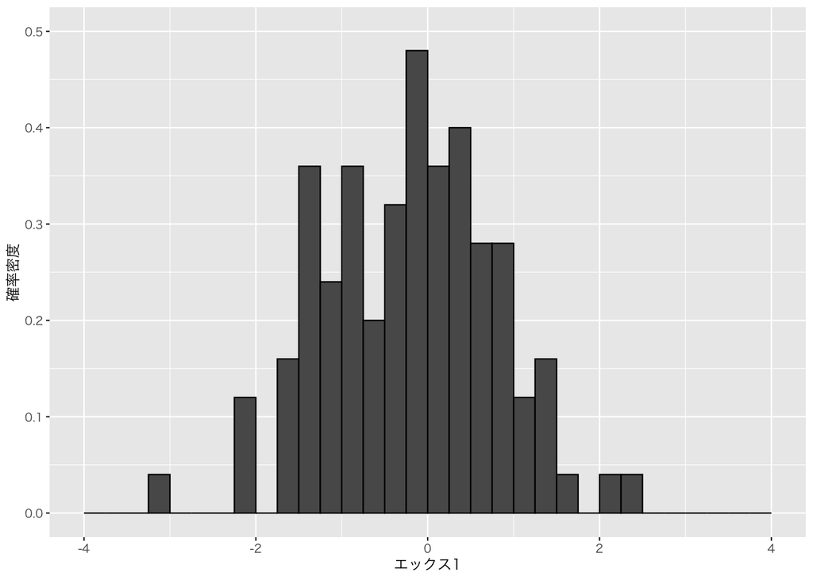

```r
p3 <- p1 +
    labs(x = "エックス1", y = "確率密度")
plot(p3)
```

授業の内容に戻る